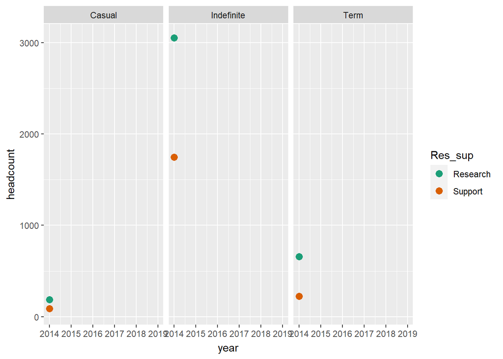

#### Elise Behn

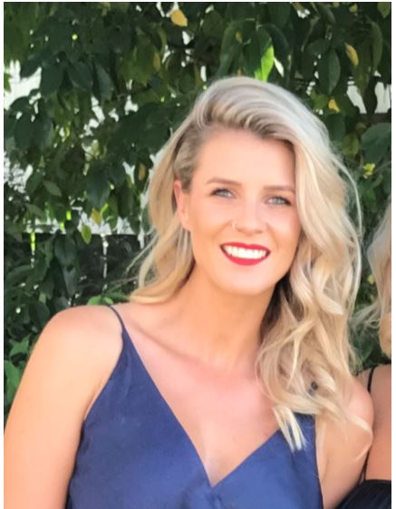

CSIRO WORKFORCE

My name is Elise Behn and I have been working with data for the past 6 years of my career, up until this point I have been mostly focused on analysing, storing and manipulating the data through available systems such as Excel. I decided to enrol in Data School for the chance to build my skills around data collection, visualisation, analysis and more importantly learn about the programming languages used to perform these tasks behind the scenes. Our team hope to be using more advanced technologies for our reporting in the near future and I believe having these types of skills will truly benefit my understanding of newer systems on the market. Before stating the Focus program i had no experience in R nor any other computer programming language. My days were spent generating reports from SAP and manipulating them in Excel. Since Focus i have already transformed the way i work from data management to simplifying repetitive processes.